# **CPE213 KMUTT Data model Project Predict survival of patients with heart failure**

Jatumongkon suksrinuan, Thornthan yasukum, Piyawat anugoolsawat, Natthaphon rojanathamcharoen, Phawit pukamkom

*Faculty of Engineering, Computer Engineering - king mongkut’s university of technology thonburi*

## Abstract

### **Cardiovascular diseases**

Cardiovascular diseases (CVDs) are disorders of the heart and blood vessels including, heart attacks, strokes, heart failure

Cardiovascular diseases cause the death of approximately 17 million people worldwide annually. In particular, heart failure occurs when the heart is unable to pump enough blood to the body, and it is usually caused by diabetes, high blood pressure, or other heart conditions or diseases.

### Objective

find the people with a high probability of death to provide immediate assistance.

### **Dataset**

https://www.kaggle.com/andrewmvd/heart-failure-clinical-data

[figure not shown]

[figure not shown]

This dataset containing the medical records of 299 heart failure patients collected at the Faisalabad Institute of Cardiology and at the Allied Hospital in Faisalabad (Punjab, Pakistan), during April–December 2015

- **Age :** Age of the patient (Year)
- **Anaemia :** Decrease of red blood cells or hemoglobin (Yes = 1, No = 0)
- **High blood pressure :** If a patient has hypertension (Yes = 1, No = 0)
- **Creatinine phosphokinase :** Level of the CPK enzyme in the blood (mcg/L)
- **Diabetes :** If the patient has diabetes (Yes = 1, No = 0)
- **Ejection fraction :** Percentage of blood leaving the heart at each contraction (Percentage)
- **Sex :** Woman or man (Man = 1, Woman=0)
- **Platelets :** Platelets in the blood (kilo platelets/mL)
- **Serum creatinine :** Level of creatinine in the blood (mg/dL)
- **Serum sodium :** Level of sodium in the blood (mEq/L)
- **Smoking :** If the patient smokes (Yes = 1, No = 0)
- **Time :** Follow-up period (Days)

#### **Death event :**If the patient died during the follow-up period (Yes = 1, No = 0)

## Table of content

- 1.Importing libraries and loading data
- 2.Data Cleaning
- 3.Data visualization
- 4.Model Explanation
  - Decision tree Hold out method 70% train 30%
- 5. Model Evaluation
  - Lift calculator of Decision tree Hold out method 70% train 30%
  - Cross validation
  - Lift calculator of Cross validation
  - Cross Validation (LOOCV)
  - Lift calculator of Cross Validation (LOOCV)
- 6.Conclusion

## Import package

```r
library(tidyverse)
library(caret)
```

```r
library(lift)
library(ROCR)
library(rpart)
library(rpart.plot)
library(readr)
set.seed(69)
```

```r
heart_failure_clinical_records_dataset <- read_csv("heart_failure_dataset.csv")
heart_failure_clinical_records_dataset
```

```
## # A tibble: 299 × 13
##      age anaemia creatinine_phospho… diabetes ejection_fracti… high_blood_press…
##    <dbl>   <dbl>               <dbl>    <dbl>            <dbl>             <dbl>
##  1    75       0                 582        0               20                 1
##  2    55       0                7861        0               38                 0
##  3    65       0                 146        0               20                 0
##  4    50       1                 111        0               20                 0
##  5    65       1                 160        1               20                 0
##  6    90       1                  47        0               40                 1
##  7    75       1                 246        0               15                 0
##  8    60       1                 315        1               60                 0
##  9    65       0                 157        0               65                 0
## 10    80       1                 123        0               35                 1
## # … with 289 more rows, and 7 more variables: platelets <dbl>,
## #   serum_creatinine <dbl>, serum_sodium <dbl>, sex <dbl>, smoking <dbl>,
## #   time <dbl>, DEATH_EVENT <dbl>
```

## Data Cleaning

1.Clean up data by removing Na data.

```r
any(is.na(heart_failure_clinical_records_dataset))
```

```
## [1] FALSE
```

2.Rename column “creatinine_phosphokinase” to “cpk” and “DEATH_EVENT” to “death” and reject time((Follow-up period (Days)) isn’t used to create a model because it is an unpredictable future story. .

```r
heart_failure_clinical_records_dataset %>% rename(
  cpk = creatinine_phosphokinase,
  death = DEATH_EVENT
) %>%
  select(-time) -> all_data
```

3.Change datatype of “death” to factor

```r
all_data$death = as.factor(all_data$death)
```

4.data after cleaning

```r
all_data
```

```
## # A tibble: 299 × 12
##      age anaemia   cpk diabetes ejection_fraction high_blood_pressure platelets
##    <dbl>   <dbl> <dbl>    <dbl>             <dbl>               <dbl>     <dbl>
##  1    75       0   582        0                20                   1   265000
##  2    55       0  7861        0                38                   0   263358.
##  3    65       0   146        0                20                   0   162000
##  4    50       1   111        0                20                   0   210000
##  5    65       1   160        1                20                   0   327000
##  6    90       1    47        0                40                   1   204000
##  7    75       1   246        0                15                   0   127000
##  8    60       1   315        1                60                   0   454000
##  9    65       0   157        0                65                   0   263358.
## 10    80       1   123        0                35                   1   388000
## # … with 289 more rows, and 5 more variables: serum_creatinine <dbl>,
## #   serum_sodium <dbl>, sex <dbl>, smoking <dbl>, death <fct>
```

## Data Exploration

1.Data type

```r
unique(all_data$age)        #Continuous
```

```
##  [1] 75.000 55.000 65.000 50.000 90.000 60.000 80.000 62.000 45.000 49.000
## [11] 82.000 87.000 70.000 48.000 68.000 53.000 95.000 58.000 94.000 85.000
## [21] 69.000 72.000 51.000 57.000 42.000 41.000 67.000 79.000 59.000 44.000
## [31] 63.000 86.000 66.000 43.000 46.000 61.000 81.000 52.000 64.000 40.000
## [41] 60.667 73.000 77.000 78.000 54.000 47.000 56.000
```

```r
unique(all_data$anaemia)    #Categorical
```

```
## [1] 0 1
```

```r
unique(all_data$cpk)        #Continuous
```

```
##   [1]  582 7861  146  111  160   47  246  315  157  123   81  231  981  168   80
##  [16]  379  149  125   52  128  220   63  148  112  122   60   70   23  249  159
##  [31]   94  855 2656  235  124  571  127  588 1380  553  129  577   91 3964   69
##  [46]  260  371   75  607  789  364 7702  318  109   68  250  110  161  113 5882
##  [61]  224   92  102  203  336   76   55  280   78   84  115   66  897  154  144
##  [76]  133  514   59  156   61  305  898 5209   53  328  748 1876  936  292  369
##  [91]  143  754  400   96  737  358  200  248  270 1808 1082  719  193 4540  646
## [106]  281 1548  805  291  482  943  185  132 1610 2261  233   30 1846  335   58
## [121]  910   72  130 2334 2442  776  196  835 3966  171  198   95 1419  478  176
## [136]  395   99  145  104 1896  151  244   62  121  418  167 1211 1767  308   97
## [151]   64  101  212 2281  972  131  135 1202  427 1021  118   86  675   57 2794
## [166]   56  211  166   93  707  119  232  720  180   90 1185 2017  624  207 2522
## [181]  572  245   88  446  191  326  655  258  298 1199  213  257  618 1051 2695
## [196] 1688   54  170  253  892  337  615  320  190  103 1820 2060 2413
```

```r
unique(all_data$diabetes)   #Categorical
```

```
## [1] 0 1
```

```r
unique(all_data$ejection_fraction)   #Continuous
```

```
##  [1] 20 38 40 15 60 65 35 25 30 50 14 55 45 62 80 17 70
```

```r
unique(all_data$high_blood_pressure) #Categorical
```

```
## [1] 1 0
```

```r
unique(all_data$platelets)           #Continuous
```

```
##   [1] 265000 263358 162000 210000 327000 204000 127000 454000 388000 368000
##  [11] 253000 136000 276000 427000  47000 262000 166000 237000  87000 297000
##  [21] 289000 149000 196000 284000 153000 200000 360000 319000 302000 188000
##  [31] 228000 226000 321000 305000 329000 185000 218000 194000 310000 271000
##  [41] 451000 140000 395000 418000 351000 255000 461000 223000 216000 254000
##  [51] 390000 385000 119000 213000 274000 244000 497000 374000 122000 243000
##  [61] 266000 317000 283000 324000 293000 172000 406000 173000 304000 235000
##  [71] 181000 249000 219000 318000 221000 298000 286000 621000 263000 850000
##  [81] 306000 252000 328000 164000 507000 203000 217000 300000 267000 227000
##  [91] 250000 295000 231000 211000 348000 229000 338000 242000 225000 184000
## [101] 277000 362000 174000 448000  75000 334000 192000 220000  70000 270000
## [111] 325000 176000 189000 281000 337000 105000 132000 279000 303000 224000
## [121] 389000 365000 201000 275000 350000 309000 260000 160000 126000 259000
## [131]  73000 377000 212000 186000 268000 147000 481000 290000 358000 151000
## [141] 371000 130000 504000 141000  62000 330000 248000 257000 533000 264000
## [151] 282000 314000 246000 301000 404000 236000 294000 233000 308000 198000
## [161] 208000 133000 222000 215000 150000 422000  25100 232000 241000  51000
## [171] 336000 543000 382000 179000 155000 742000
```

```r
unique(all_data$serum_creatinine)    #Continuous
```

```
##  [1] 1.90 1.10 1.30 2.70 2.10 1.20 1.50 9.40 4.00 0.90 1.00 0.80 1.60 1.83 5.80
## [16] 3.00 3.50 2.30 0.60 4.40 1.40 6.80 2.20 2.00 1.18 2.90 0.70 1.70 2.50 1.80
## [31] 3.20 0.75 3.70 3.40 6.10 2.40 9.00 5.00 0.50 3.80
```

```r
unique(all_data$serum_sodium)        #Continuous
```

```
##  [1] 130 136 129 137 116 132 131 138 133 140 127 121 135 134 144 128 145 142 139
## [20] 146 141 143 126 124 113 125 148
```

```r
unique(all_data$sex)     #Categorical
```

```
## [1] 1 0
```

```r
unique(all_data$smoking) #Categorical
```

```
## [1] 0 1
```

```r
unique(all_data$death)   #Response y is Categorical
```

```
## [1] 1 0
## Levels: 0 1
```

| Categorical | Numerical |
| --- | --- |
| Anaemia | Age |
| High blood pressure | Creatinine phosphokinase |
| diabetes | Ejection fraction |
| sex | platelets |
| smoking | Serum creatinine |
|  | Serum sodium |

2.Ratio of categorical

```r
summary(all_data$death)
```

```
##   0   1
## 203  96
```

A total of **299** patients were surveyed: **203** Alive and **96** Died

```r
summary(as.factor(all_data$sex))
```

```
##   0   1
## 105 194
```

A total of **299** patients: 105 women and 194 man

```r
summary(as.factor(all_data$smoking))
```

```
##   0   1
## 203  96
```

A total of **299** patients: 96 smoking and 203 non-smoking

```r
summary(as.factor(all_data$diabetes))
```

```
##   0   1
## 174 125
```

A total of **299** patients: 125 patients have diabetes and 174 patients don’t have diabetes

```r
summary(as.factor(all_data$high_blood_pressure))
```

```
##   0   1
## 194 105
```

## Data visualization

1.Distribution of age

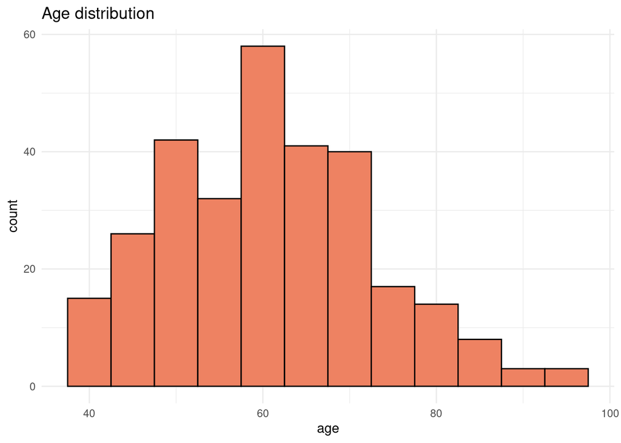

```r
ggplot(all_data, aes(age)) +
  geom_histogram(binwidth = 5,colour = "black", fill="salmon2") +
  labs(title = "Age distribution")+
  theme_minimal()
```

```r
summary(all_data$age)
```

```
##    Min. 1st Qu.  Median    Mean 3rd Qu.    Max.
##   40.00   51.00   60.00   60.83   70.00   95.00
```

from histogram and summary statistic . age of patients are right skewed and their ages range between 40 and 95 years old

2. Scatter plot of blood data

[output not shown]

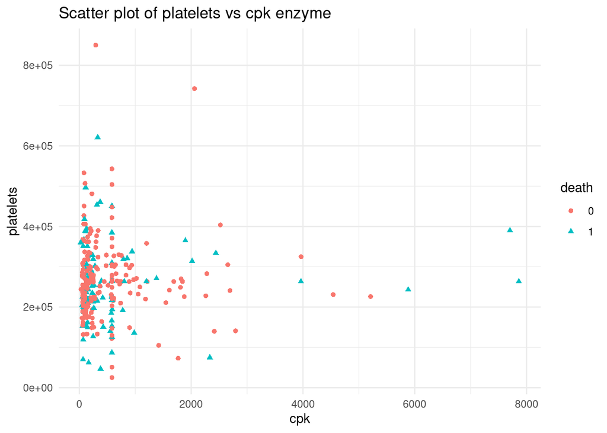

```r
ggplot(all_data) +
  geom_point(aes(x = cpk, y = platelets, color = death,shape=death))+
  labs(title = "Scatter plot of platelets vs cpk enzyme")+
  theme_minimal()
```

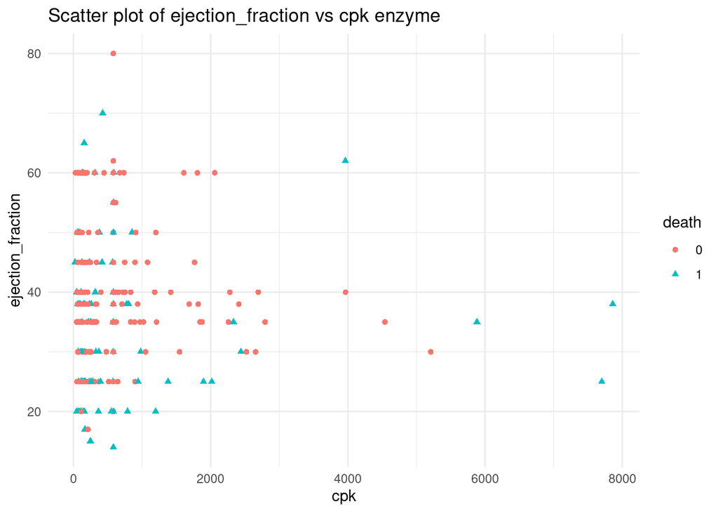

```r
ggplot(all_data) +
  geom_point(aes(x = cpk, y = ejection_fraction, color = death,shape=death))+
  labs(title = "Scatter plot of ejection_fraction vs cpk enzyme")+
  theme_minimal()
```

From Scatter plot of serum ejection_fraction and enzyme CPK in blood that similar result as Scatter plot of serum platelets and enzyme CPK in blood, Graphs cannot be divided into two groups or arranged in a straight line.

## Model Explanation

### 1.Decision tree Hold out method 70% train 30%

```r
#Separate train and test data
n <- nrow(all_data)
test_index <- sample(1:n,size =  0.3*n)
data_train <- all_data[-test_index,] #train 0.7
data_test <- all_data[test_index,]   #test 0.3
```

```r
#Summary train and test dataset
summary(data_test$death)
```

```
##  0  1
## 65 24
```

```r
summary(data_train$death)
```

```
##   0   1
## 138  72
```

#### Train model

```r
#Train model
model1 <- rpart(death~., data = data_train)
```

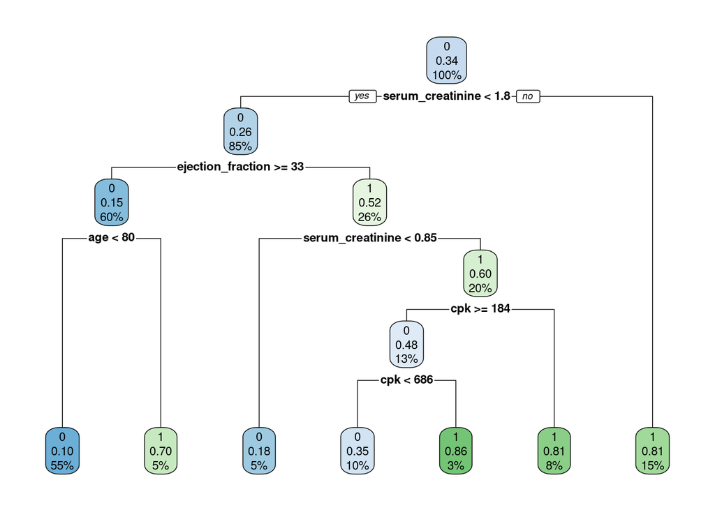

```r
rpart.plot(model1)
```

```r
model1$variable.importance
```

```
##  serum_creatinine ejection_fraction               age               cpk
##        19.0900360        10.1314728         8.5567409         5.8064246
##               sex         platelets      serum_sodium
##         0.6880181         0.6562352         0.1376036
```

```r
summary(model1)$cptable
```

```
## Call:
## rpart(formula = death ~ ., data = data_train)
##   n= 210
##
##           CP nsplit rel error    xerror       xstd
## 1 0.26388889      0 1.0000000 1.0000000 0.09553525
## 2 0.06250000      1 0.7361111 0.9166667 0.09343532
## 3 0.05555556      3 0.6111111 0.8750000 0.09223310
## 4 0.04166667      4 0.5555556 0.7500000 0.08796644
## 5 0.01000000      6 0.4722222 0.5833333 0.08050765
##
## Variable importance
##  serum_creatinine ejection_fraction               age               cpk
##                42                22                19                13
##               sex         platelets
##                 2                 1
##
## Node number 1: 210 observations,    complexity param=0.2638889
##   predicted class=0  expected loss=0.3428571  P(node) =1
##     class counts:   138    72
##    probabilities: 0.657 0.343
##   left son=2 (179 obs) right son=3 (31 obs)
##   Primary splits:
##       serum_creatinine  < 1.815  to the left,  improve=15.632720, (0 missing)
##       ejection_fraction < 32.5   to the right, improve=12.984410, (0 missing)
##       age               < 71     to the left,  improve= 7.866807, (0 missing)
##       serum_sodium      < 136.5  to the right, improve= 5.283804, (0 missing)
##       cpk               < 2297.5 to the left,  improve= 1.971855, (0 missing)
##   Surrogate splits:
##       age < 92     to the left,  agree=0.857, adj=0.032, (0 split)
##
## Node number 2: 179 observations,    complexity param=0.0625
##   predicted class=0  expected loss=0.2625698  P(node) =0.852381
##     class counts:   132    47
##    probabilities: 0.737 0.263
##   left son=4 (125 obs) right son=5 (54 obs)
##   Primary splits:
##       ejection_fraction < 32.5   to the right, improve=10.131470, (0 missing)
##       age               < 79.5   to the left,  improve= 4.200671, (0 missing)
##       serum_creatinine  < 0.85   to the left,  improve= 3.437117, (0 missing)
```

[output cut: 84 more lines]

```
##
## Node number 23: 16 observations
##   predicted class=1  expected loss=0.1875  P(node) =0.07619048
##     class counts:     3    13
##    probabilities: 0.187 0.812
##
## Node number 44: 20 observations
##   predicted class=0  expected loss=0.35  P(node) =0.0952381
##     class counts:    13     7
##    probabilities: 0.650 0.350
##
## Node number 45: 7 observations
##   predicted class=1  expected loss=0.1428571  P(node) =0.03333333
##     class counts:     1     6
##    probabilities: 0.143 0.857
```

```
##           CP nsplit rel error    xerror       xstd
## 1 0.26388889      0 1.0000000 1.0000000 0.09553525
## 2 0.06250000      1 0.7361111 0.9166667 0.09343532
## 3 0.05555556      3 0.6111111 0.8750000 0.09223310
## 4 0.04166667      4 0.5555556 0.7500000 0.08796644
## 5 0.01000000      6 0.4722222 0.5833333 0.08050765
```

#### **Test model**

```r
#Test Model
res1 <- predict(model1, data_test, type = 'class')
#class type return factor ('0', '1')
```

```r
head(res1)
```

```
## 1 2 3 4 5 6
## 0 0 1 1 1 1
## Levels: 0 1
```

```r
confusionMatrix(res1, data_test$death, positive = "1")
```

```
## Confusion Matrix and Statistics
##
##           Reference
## Prediction  0  1
##          0 53  9
##          1 12 15
##
##                Accuracy : 0.764
##                  95% CI : (0.6622, 0.8476)
##     No Information Rate : 0.7303
##     P-Value [Acc > NIR] : 0.2793
##
##                   Kappa : 0.4237
##
##  Mcnemar's Test P-Value : 0.6625
##
##             Sensitivity : 0.6250
##             Specificity : 0.8154
##          Pos Pred Value : 0.5556
##          Neg Pred Value : 0.8548
##              Prevalence : 0.2697
##          Detection Rate : 0.1685
##    Detection Prevalence : 0.3034
##       Balanced Accuracy : 0.7202
##
##        'Positive' Class : 1
##
```

```r
confusionMatrix(res1, data_test$death, positive = "1", mode = 'prec_recall')
```

```
## Confusion Matrix and Statistics
##
##           Reference
## Prediction  0  1
##          0 53  9
##          1 12 15
##
##                Accuracy : 0.764
##                  95% CI : (0.6622, 0.8476)
##     No Information Rate : 0.7303
##     P-Value [Acc > NIR] : 0.2793
##
##                   Kappa : 0.4237
##
##  Mcnemar's Test P-Value : 0.6625
##
##               Precision : 0.5556
##                  Recall : 0.6250
##                      F1 : 0.5882
##              Prevalence : 0.2697
##          Detection Rate : 0.1685
##    Detection Prevalence : 0.3034
##       Balanced Accuracy : 0.7202
##
##        'Positive' Class : 1
##
```

## Model Evaluation

*Lift Calculation*

$Lift = P(Yes | Model)/P(Yes)$

After we got model. we should to test model performance. in this project we use classification model so Lift is tool for test performance of classification model.

“Lift use for compare normal random and random with model, what is the better choice”

### 1.Lift Calculation of Model (Decision tree Hold out method 70% train 30%)

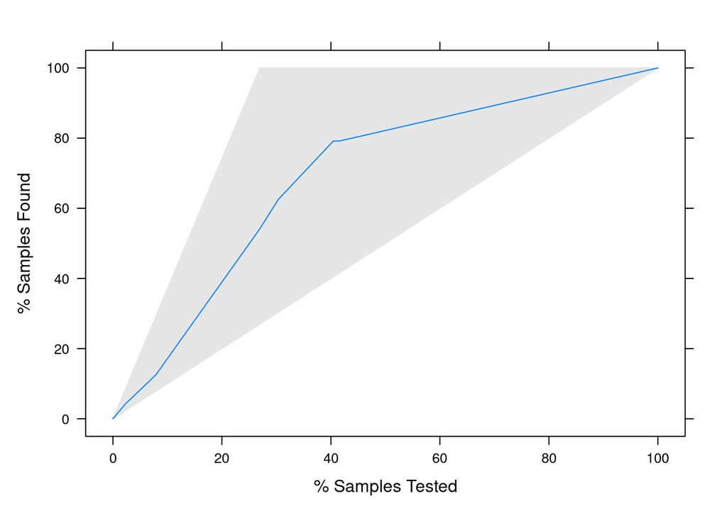

```r
#Lift Calculation of Model1
res1_pos <- predict(model1, data_test)[,'1']
lift_result1 <- data.frame(prob = res1_pos, y = data_test$death)
lift_obj1 <- lift(y ~ prob, data = lift_result1, class = '1')
plot(lift_obj1) #add parameter values (determine %sample found) to find %sample tested
```

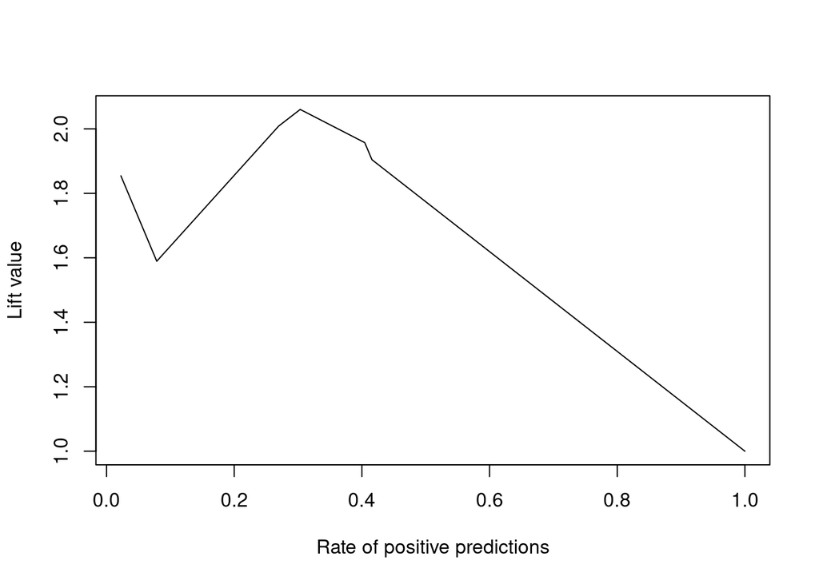

```r
pred1 <- prediction(res1_pos, data_test$death, label.ordering = c('0', '1'))
perf_lift1 <- performance(pred1, 'lift', 'rpp')
plot(perf_lift1)
```

```r
tdl1 <- TopDecileLift(res1_pos, as.integer(data_test$death)-1)
tdl1
```

```
## [1] 1.648
```

### 2.Cross Validation (CV)

After we test with lift calculation. the problem when we split the train and test model that effective model overfit. Now we should to split with K-Fold Cross Validation for split data to 10 round to split and test data for select the best split

[figure not shown]

```r
#Cross Validation
train_control <- trainControl(method = 'cv', number = 10)
model_cv <- train(death~. ,
                  data = data_train,
                  trControl = train_control,
                  method = 'rpart')
model_cv
```

```
## CART
##
## 210 samples
##  11 predictor
##   2 classes: '0', '1'
##
## No pre-processing
## Resampling: Cross-Validated (10 fold)
## Summary of sample sizes: 188, 189, 188, 189, 190, 189, ...
## Resampling results across tuning parameters:
##
##   cp          Accuracy   Kappa
##   0.05555556  0.7403680  0.4129863
##   0.06250000  0.7165152  0.3298181
##   0.26388889  0.6854113  0.1295218
##
## Accuracy was used to select the optimal model using the largest value.
## The final value used for the model was cp = 0.05555556.
```

```r
model_cv$finalModel #get new model
```

```
## n= 210
##
## node), split, n, loss, yval, (yprob)
##       * denotes terminal node
##
##  1) root 210 72 0 (0.6571429 0.3428571)
##    2) serum_creatinine< 1.815 179 47 0 (0.7374302 0.2625698)
##      4) ejection_fraction>=32.5 125 19 0 (0.8480000 0.1520000) *
##      5) ejection_fraction< 32.5 54 26 1 (0.4814815 0.5185185)
##       10) serum_creatinine< 0.85 11  2 0 (0.8181818 0.1818182) *
##       11) serum_creatinine>=0.85 43 17 1 (0.3953488 0.6046512) *
##    3) serum_creatinine>=1.815 31  6 1 (0.1935484 0.8064516) *
```

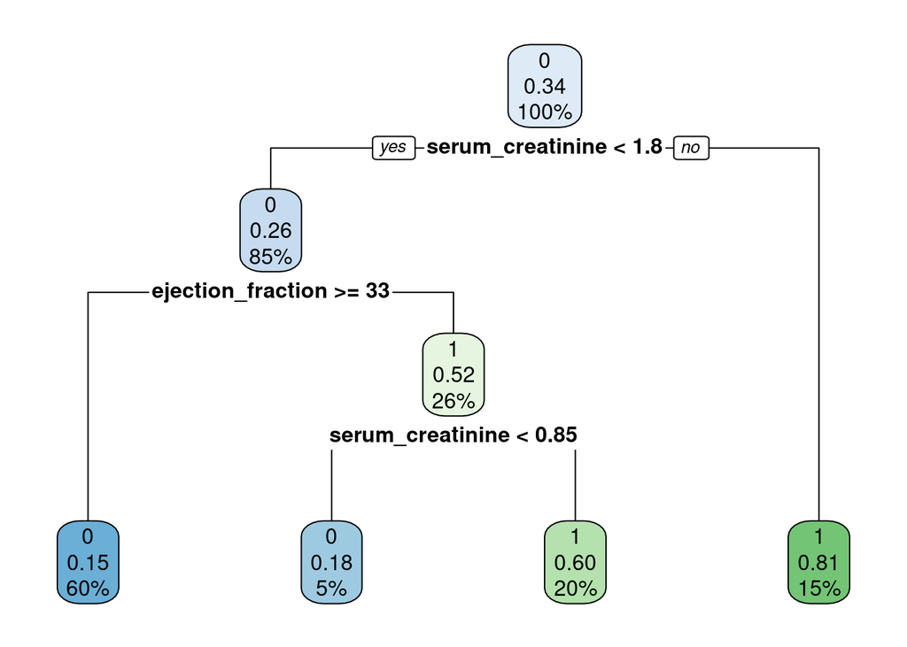

```r
model_final <- model_cv$finalModel
rpart.plot(model_final)
```

```r
model_final$variable.importance
```

```
##  serum_creatinine ejection_fraction               age               cpk
##        18.9524323        10.1314728         0.5042812         0.2847360
```

```r
#Test Model from CV
res2 <- predict(model_final, data_test, type = 'class')
head(res2)
```

```
## 1 2 3 4 5 6
## 0 0 1 0 1 1
## Levels: 0 1
```

```r
confusionMatrix(res2, data_test$death, positive = "1")
```

```
## Confusion Matrix and Statistics
##
##           Reference
## Prediction  0  1
##          0 49  7
##          1 16 17
##
##                Accuracy : 0.7416
##                  95% CI : (0.6379, 0.8286)
##     No Information Rate : 0.7303
##     P-Value [Acc > NIR] : 0.45974
##
##                   Kappa : 0.4133
##
##  Mcnemar's Test P-Value : 0.09529
##
##             Sensitivity : 0.7083
##             Specificity : 0.7538
##          Pos Pred Value : 0.5152
##          Neg Pred Value : 0.8750
##              Prevalence : 0.2697
##          Detection Rate : 0.1910
##    Detection Prevalence : 0.3708
##       Balanced Accuracy : 0.7311
##
##        'Positive' Class : 1
##
```

```r
confusionMatrix(res2, data_test$death, positive = "1", mode = 'prec_recall')
```

```
## Confusion Matrix and Statistics
##
##           Reference
## Prediction  0  1
##          0 49  7
##          1 16 17
##
##                Accuracy : 0.7416
##                  95% CI : (0.6379, 0.8286)
##     No Information Rate : 0.7303
##     P-Value [Acc > NIR] : 0.45974
##
##                   Kappa : 0.4133
##
##  Mcnemar's Test P-Value : 0.09529
##
##               Precision : 0.5152
##                  Recall : 0.7083
##                      F1 : 0.5965
##              Prevalence : 0.2697
##          Detection Rate : 0.1910
##    Detection Prevalence : 0.3708
##       Balanced Accuracy : 0.7311
##
##        'Positive' Class : 1
##
```

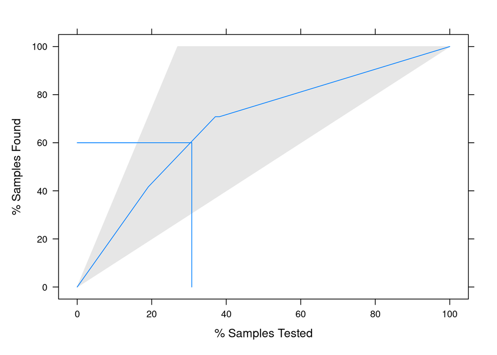

```r
#Lift Calculation of Model from CV
res2_pos <- predict(model_final, data_test)[,'1']
lift_result2 <- data.frame(prob = res2_pos, y = data_test$death)
lift_obj2 <- lift(y ~ prob, data = lift_result2, class = '1')
plot(lift_obj2, values = 60) #add parameter values (determine %sample found) to find %sample tested
```

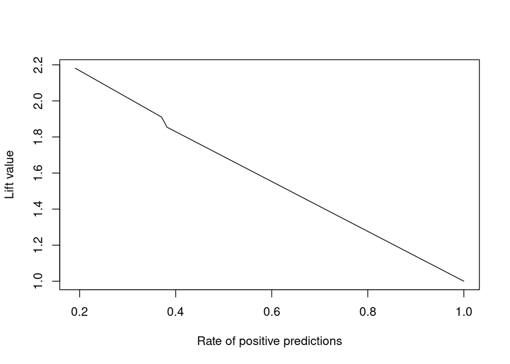

```r
pred2 <- prediction(res2_pos, data_test$death, label.ordering = c('0', '1'))
perf_lift2 <- performance(pred2, 'lift', 'rpp')
plot(perf_lift2)
```

```r
tdl2 <- TopDecileLift(res2_pos, as.integer(data_test$death)-1)
tdl2
```

```
## [1] 2.472
```

#### 3.Cross Validation (LOOCV)

LOOCV similar technical as K-FLOD but the different is number of split is the record of data and split with one set for test and other for train to build model

```r
#Cross Validation LOOCV
train_control_one <- trainControl(method = 'LOOCV', number = 10)
model_cv_one <- train(death~. ,
                  data = all_data,
                  trControl = train_control_one,
                  method = 'rpart')
```

```r
model_cv_one
```

```
## CART
##
## 299 samples
##  11 predictor
##   2 classes: '0', '1'
##
## No pre-processing
## Resampling: Leave-One-Out Cross-Validation
## Summary of sample sizes: 298, 298, 298, 298, 298, 298, ...
## Resampling results across tuning parameters:
##
##   cp          Accuracy   Kappa
##   0.06250000  0.6822742   0.21287444
##   0.08333333  0.6956522   0.23696682
##   0.22916667  0.6354515  -0.08293737
##
## Accuracy was used to select the optimal model using the largest value.
## The final value used for the model was cp = 0.08333333.
```

```r
model_cv_one$finalModel #get new model
```

```
## n= 299
##
## node), split, n, loss, yval, (yprob)
##       * denotes terminal node
##
## 1) root 299 96 0 (0.6789298 0.3210702)
##   2) serum_creatinine< 1.815 251 61 0 (0.7569721 0.2430279) *
##   3) serum_creatinine>=1.815 48 13 1 (0.2708333 0.7291667) *
```

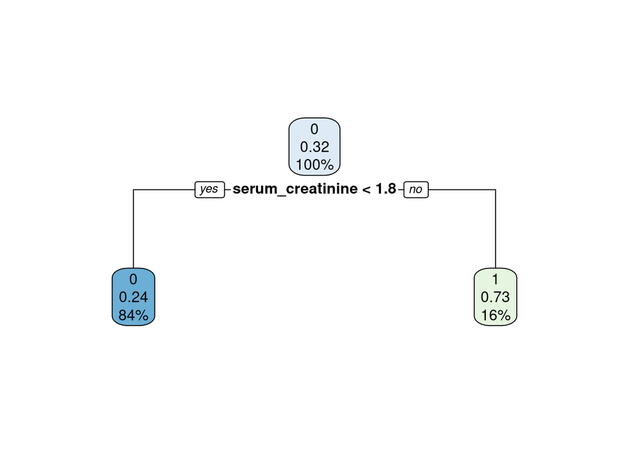

```r
model_final_one <- model_cv_one$finalModel
rpart.plot(model_final_one)
```

```r
model_final_one$variable.importance
```

```
## serum_creatinine     serum_sodium              age
##        19.045584         0.793566         0.396783
```

```r
#Test Model from LOOCV
res2_one <- predict(model_final_one, data_test, type = 'class')
head(res2_one)
```

```
## 1 2 3 4 5 6
## 0 0 0 0 1 0
## Levels: 0 1
```

```r
confusionMatrix(res2_one, data_test$death, positive = "1")
```

```
## Confusion Matrix and Statistics
##
##           Reference
## Prediction  0  1
##          0 58 14
##          1  7 10
##
##                Accuracy : 0.764
##                  95% CI : (0.6622, 0.8476)
##     No Information Rate : 0.7303
##     P-Value [Acc > NIR] : 0.2793
##
##                   Kappa : 0.3403
##
##  Mcnemar's Test P-Value : 0.1904
##
##             Sensitivity : 0.4167
##             Specificity : 0.8923
##          Pos Pred Value : 0.5882
##          Neg Pred Value : 0.8056
##              Prevalence : 0.2697
##          Detection Rate : 0.1124
##    Detection Prevalence : 0.1910
##       Balanced Accuracy : 0.6545
##
##        'Positive' Class : 1
##
```

```r
confusionMatrix(res2_one, data_test$death, positive = "1", mode = 'prec_recall')
```

```
## Confusion Matrix and Statistics
##
##           Reference
## Prediction  0  1
##          0 58 14
##          1  7 10
##
##                Accuracy : 0.764
##                  95% CI : (0.6622, 0.8476)
##     No Information Rate : 0.7303
##     P-Value [Acc > NIR] : 0.2793
##
##                   Kappa : 0.3403
##
##  Mcnemar's Test P-Value : 0.1904
##
##               Precision : 0.5882
##                  Recall : 0.4167
##                      F1 : 0.4878
##              Prevalence : 0.2697
##          Detection Rate : 0.1124
##    Detection Prevalence : 0.1910
##       Balanced Accuracy : 0.6545
##
##        'Positive' Class : 1
##
```

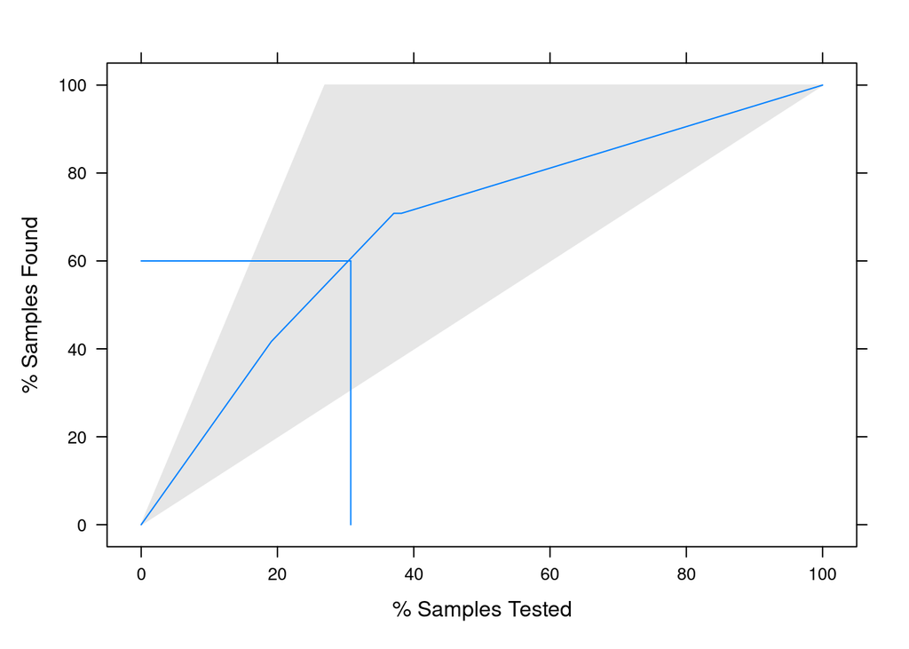

```r
#Lift Calculation of Model from CV
res3_pos <- predict(model_final_one, data_test)[,'1']
lift_result3 <- data.frame(prob = res3_pos, y = data_test$death)
lift_ob32 <- lift(y ~ prob, data = lift_result3, class = '1')
plot(lift_obj2, values = 60) #add parameter values (determine %sample found) to find %sample tested
```

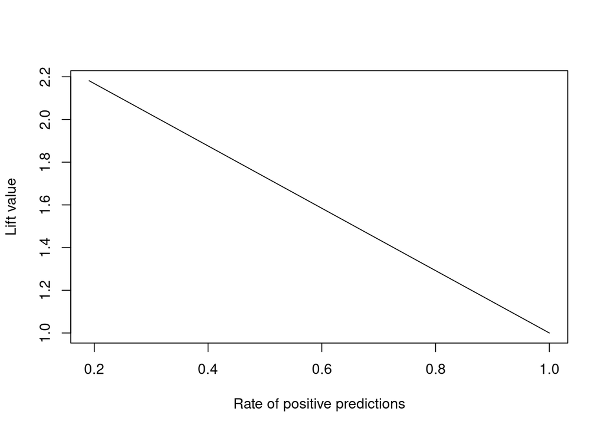

```r
pred3 <- prediction(res3_pos, data_test$death, label.ordering = c('0', '1'))
perf_lift3 <- performance(pred3, 'lift', 'rpp')
plot(perf_lift3)
```

```r
tdl3 <- TopDecileLift(res3_pos, as.integer(data_test$death)-1)
tdl3
```

```
## [1] 2.472
```

## **Conclusion**

The amount of information is sparse. In real situation the accuracy of the model isn’t high enough to consider who have high risk of mortality but can be used to basic diagnostics.

| Method | Adventage | Disadventage |
| --- | --- | --- |
| Holdout (70% train 30% test) | Fast | Unfortunate Split, Overfitting, Complex Tree |
| Cross validation | Solve Overfit Model and Selection Bias | Can’t predict |
| Holdout-cross-validation (train data cross-validation) | Solve Overfit Model and Selection Bias | Amount Train Data Decrease |

**Supplementary information**

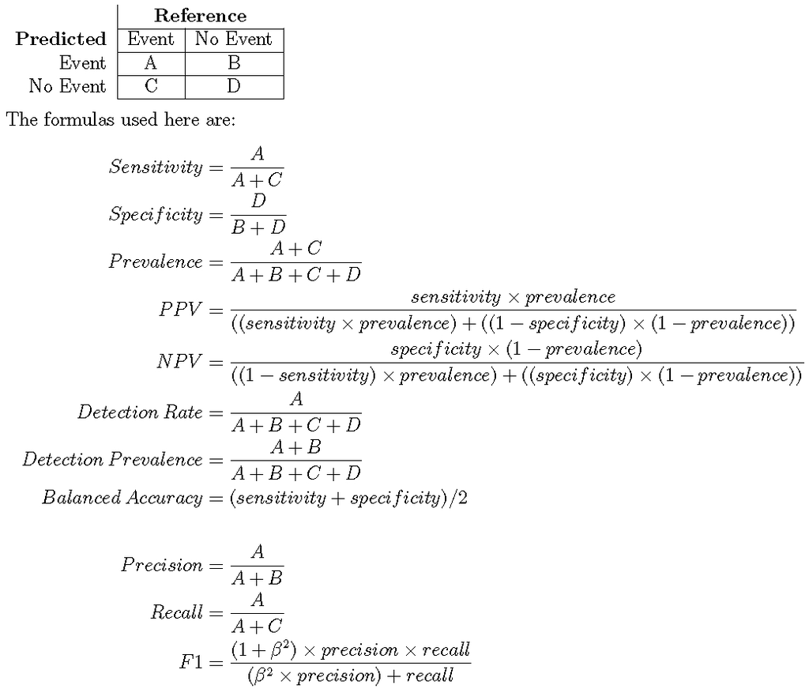

**Reference**

Ref:[<https://bmcmedinformdecismak.biomedcentral.com/articles/10.1186/s12911-020-1023-5>](https://bmcmedinformdecismak.biomedcentral.com/articles/10.1186/s12911-020-1023-5)

Ref:https://topepo.github.io/caret/measuring-performance.html